# phenos_summary

2024-06-13

## *Inclusion/Exclusion criteria*

- No diabetes data (Eastwood algorithm + HbA1c <5.7%)
- Complete data for glucose, genetic ancestry, and behavioral/SES covariates

#### Planned sensitivity analyses

- Restrict to individuals with plausible total energy intakes
- (<20MJ for men; <18 MJ for women)

| N_European | 362458 (100%) |
| --- | --- |
| N_geno | 362075 (99.9%) |
| N_contrl | 279805 (77.2%) |
| N_contrl_compl | 242220 (66.8%) |
| N_contrl_compl_kcal | 98663 (27.2%) |
| N_contrl_compl_kcal_taste | 89269 (24.6%) |

```
## [1] 241955    170
```

## Distribution of TAS2R38 Haplotypes & Diplotypes

We examined the distributions of common (frequency >0.0005) TAS2R38 genotypess

```
## Defaulting to continuous.
## Defaulting to continuous.
```

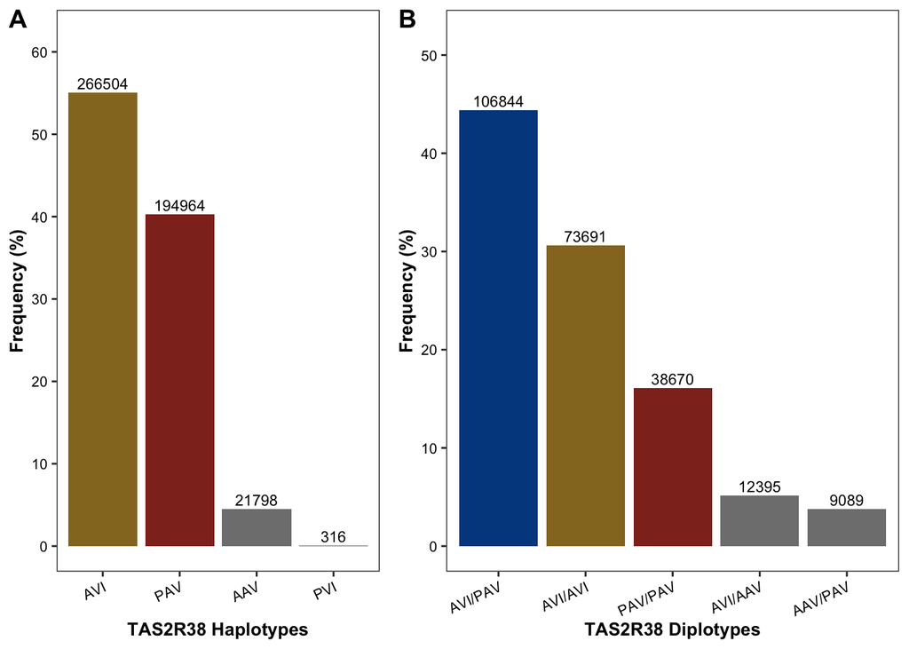

## Descriptive characteristics

We summarized demographic, behavioral and health characteristics among all identified TAS2R38 diplotypes.

|  | Total | AVI/AVI | AVI/PAV | PAV/PAV | AVI/AAV | AAV/PAV | P_value |
| --- | --- | --- | --- | --- | --- | --- | --- |
| Age, years | 56 ± 8.1 | 56 ± 8.1 | 56.1 ± 8.1 | 56.1 ± 8.1 | 56.1 ± 8.1 | 56.1 ± 8.1 | 0.847 |
| Sex |  |  |  |  |  |  | 0.9572 |
| Male | 110031 (46%) | 33672 (46%) | 48782 (46%) | 17711 (46%) | 5689 (46%) | 4177 (46%) |  |
| Female | 130658 (54%) | 40019 (54%) | 58062 (54%) | 20959 (54%) | 6706 (54%) | 4912 (54%) |  |
| BMI, kg/m2 | 26.9 ± 4.4 | 26.9 ± 4.4 | 26.9 ± 4.4 | 26.9 ± 4.4 | 26.9 ± 4.4 | 26.9 ± 4.4 | 0.824 |
| Smoking |  |  |  |  |  |  | 0.4698 |
| Never | 135279 (56%) | 41519 (56%) | 59897 (56%) | 21771 (56%) | 6931 (56%) | 5161 (57%) |  |
| Previous | 82799 (34%) | 25306 (34%) | 36852 (34%) | 13325 (34%) | 4274 (34%) | 3042 (33%) |  |
| Current | 22611 (9%) | 6866 (9%) | 10095 (9%) | 3574 (9%) | 1190 (10%) | 886 (10%) |  |
| Physical Activity, MET/wk |  |  |  |  |  |  | 0.4194 |
| Low | 54730 (23%) | 16626 (23%) | 24388 (23%) | 8723 (23%) | 2898 (23%) | 2095 (23%) |  |
| Moderate | 136119 (57%) | 41754 (57%) | 60405 (57%) | 21955 (57%) | 6893 (56%) | 5112 (56%) |  |
| High | 49840 (21%) | 15311 (21%) | 22051 (21%) | 7992 (21%) | 2604 (21%) | 1882 (21%) |  |
| Alcohol Frequency |  |  |  |  |  |  | 0.0085 |
| Daily or almost daily | 53963 (22%) | 16705 (23%) | 24005 (22%) | 8470 (22%) | 2833 (23%) | 1950 (21%) |  |
| 3-4 per week | 60687 (25%) | 18578 (25%) | 27013 (25%) | 9646 (25%) | 3117 (25%) | 2333 (26%) |  |
| 1-2 per week | 63403 (26%) | 19515 (26%) | 27835 (26%) | 10285 (27%) | 3332 (27%) | 2436 (27%) |  |
| 1-3 per month | 25767 (11%) | 7803 (11%) | 11507 (11%) | 4176 (11%) | 1271 (10%) | 1010 (11%) |  |
| Special occasions only | 22866 (10%) | 6891 (9%) | 10201 (10%) | 3787 (10%) | 1137 (9%) | 850 (9%) |  |
| Never1 | 14003 (6%) | 4199 (6%) | 6283 (6%) | 2306 (6%) | 705 (6%) | 510 (6%) |  |
| Alcohol intake | 15.8 ± 20.2 | 15.8 ± 20.2 | 15.5 ± 20 | 15.7 ± 20.2 | 15.8 ± 20.4 | 15.8 ± 20.2 | 0.4055 |
| Education Level |  |  |  |  |  |  | 0.2283 |
| College or university degree | 81599 (34%) | 25053 (34%) | 36196 (34%) | 13111 (34%) | 4239 (34%) | 3000 (33%) |  |
| NVQ/HND or equivalent | 15233 (6%) | 4629 (6%) | 6786 (6%) | 2444 (6%) | 818 (7%) | 556 (6%) |  |
| Other professional qualifications | 12016 (5%) | 3752 (5%) | 5217 (5%) | 1981 (5%) | 614 (5%) | 452 (5%) |  |
| A/AS levels or equivalent | 28459 (12%) | 8713 (12%) | 12747 (12%) | 4430 (11%) | 1470 (12%) | 1099 (12%) |  |
| O/GCSE levels or equivalent | 52497 (22%) | 16130 (22%) | 23331 (22%) | 8447 (22%) | 2592 (21%) | 1997 (22%) |  |
| CSEs or equivalent | 13215 (6%) | 4059 (6%) | 5858 (5%) | 2136 (6%) | 667 (5%) | 495 (5%) |  |
| None of the above | 35846 (15%) | 10822 (15%) | 15900 (15%) | 5812 (15%) | 1895 (15%) | 1417 (16%) |  |
| Income Level |  |  |  |  |  |  | 0.1383 |
| lt_18000 | 40726 (19%) | 12608 (17%) | 17906 (17%) | 6601 (17%) | 2038 (16%) | 1573 (17%) |  |
| from_18000_to_30999 | 51721 (25%) | 15927 (22%) | 22884 (21%) | 8251 (21%) | 2725 (22%) | 1934 (21%) |  |
| from_31000_to_51999 | 57117 (27%) | 17589 (24%) | 25376 (24%) | 9065 (23%) | 2940 (24%) | 2147 (24%) |  |
| from_52000_to_100000 | 47151 (23%) | 14153 (19%) | 21212 (20%) | 7597 (20%) | 2417 (19%) | 1772 (19%) |  |
| gt_100000 | 12612 (6%) | 3857 (5%) | 5542 (5%) | 2069 (5%) | 661 (5%) | 483 (5%) |  |
| Glucose, mmol/L | 4.9 ± 0.6 | 4.9 ± 0.6 | 4.9 ± 0.6 | 4.9 ± 0.6 | 4.9 ± 0.6 | 4.9 ± 0.6 | 0.2136 |
| HbA1C, % | 5.3 ± 0.3 | 5.3 ± 0.3 | 5.3 ± 0.3 | 5.3 ± 0.3 | 5.3 ± 0.3 | 5.3 ± 0.3 | 0.2583 |
| SBP, mmHg | 139.1 ± 19.6 | 139.2 ± 19.6 | 139.2 ± 19.6 | 139.5 ± 19.7 | 139.2 ± 19.5 | 139.2 ± 19.6 | 0.23 |
| DBP, mmHg | 82.1 ± 10.7 | 82.1 ± 10.7 | 82.1 ± 10.6 | 82.3 ± 10.6 | 82.1 ± 10.7 | 82.1 ± 10.7 | 0.3305 |
| Triglyceride, mmol/L | 1.7 ± 1 | 1.7 ± 1 | 1.7 ± 1 | 1.7 ± 1 | 1.7 ± 1 | 1.7 ± 1 | 0.7102 |
| LDL, mmol/L | 3.6 ± 0.8 | 3.6 ± 0.8 | 3.6 ± 0.8 | 3.6 ± 0.8 | 3.6 ± 0.8 | 3.6 ± 0.8 | 0.2931 |
| HDL, mmol/L | 1.5 ± 0.4 | 1.5 ± 0.4 | 1.5 ± 0.4 | 1.5 ± 0.4 | 1.5 ± 0.4 | 1.5 ± 0.4 | 0.5509 |
| Coffee, cups/day | 2.1 ± 2 | 2.1 ± 2 | 2 ± 2 | 2.1 ± 2 | 2.1 ± 2 | 2.1 ± 2 | 0.0054 |
| Tea, cups/day | 3.4 ± 2.7 | 3.4 ± 2.7 | 3.5 ± 2.7 | 3.4 ± 2.7 | 3.5 ± 2.8 | 3.4 ± 2.7 | 0.0075 |
| Added salt |  |  |  |  |  |  | 0 |
| Never/Rarely | 137268 (57%) | 41124 (56%) | 61132 (57%) | 22753 (59%) | 6947 (56%) | 5312 (58%) |  |
| Always/Often | 37123 (15%) | 11834 (16%) | 16400 (15%) | 5534 (14%) | 2005 (16%) | 1350 (15%) |  |
| Sometimes | 66287 (28%) | 20728 (28%) | 29309 (27%) | 10380 (27%) | 3443 (28%) | 2427 (27%) |  |

```
##    AVI/AVI    AVI/PAV    PAV/PAV    AVI/AAV    AAV/PAV
## "139 ± 20" "139 ± 20" "139 ± 20" "139 ± 20" "139 ± 19"
```

```
##   AVI/AVI   AVI/PAV   PAV/PAV   AVI/AAV   AAV/PAV
## "82 ± 11" "82 ± 11" "82 ± 11" "82 ± 11" "82 ± 11"
```

Check whether diplotypes captured expected phenotypic differences in bitter-related diet traits

|  | Model | beta | se | p |
| --- | --- | --- | --- | --- |
| taste_diplos.num | Coffee | -0.022 | 0.006 | 0.000 |
| taste_diplos.num1 | Tea | 0.027 | 0.008 | 0.001 |
| taste_diplos.num2 | Raw vegetables | -0.013 | 0.006 | 0.042 |
| taste_diplos.num3 | Heavy drinker | -0.019 | 0.006 | 0.002 |
| taste_diplos.num4 | Heavy drinker | 0.028 | 0.009 | 0.001 |

## Compare food choice patterns across TAS2R38 diplotypes

We next compared diet PCs by TAS2R38 dipltype to confirm the diplotype corresponding to the most sensitive bitter taste

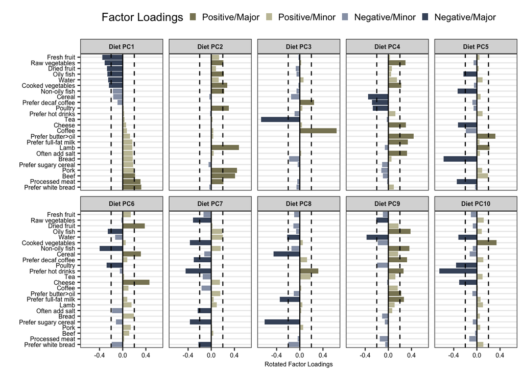

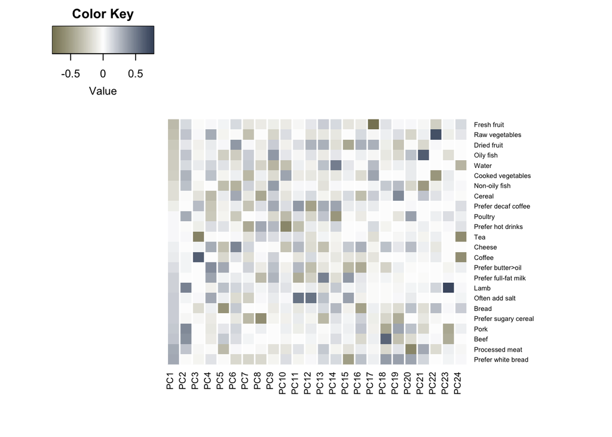

Then, we examined how adherence to the patterns differed by [common] TAS2R38 diplotypes

```
## Caution: You lose important information if you filter this package's results.
## See '? untidy'
```

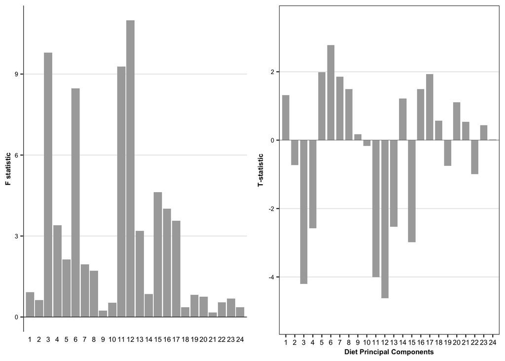

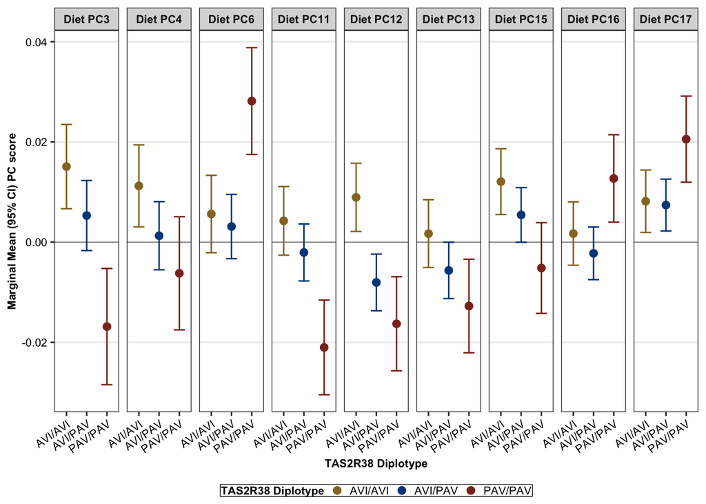

## Primary Regression Analysis

#### Asssociations of canonical TAS2R38 diplotype with markers of glucose homeostasis random glucose (RG) & hba1c (a1c)

For the primary analysis of TAS2R38 diplotype with random glucose, we used generalized linear models with 4 sets of covariates. * Exposure: categorical diplotype (reference = AVI/AVI) * Outcomes: continunous glucose traits * Covariates: 4 models; base, bmi, lifestyle, food choices

| Model | Diplotype | n | Beta_95CI_RG | P_RG | Ftest_P_RG | Ttest_P_RG | Beta_95CI_HbA1c | P_HbA1c | Ftest_P_HbA1c | Ttest_P_HbA1c |
| --- | --- | --- | --- | --- | --- | --- | --- | --- | --- | --- |
| Base_AVI/AVI | AVI/AVI | 73691 | Reference | NA | 0.139 | 0.060 | Reference | NA | 0.228 | 0.355 |
| Base_AVI/PAV | AVI/PAV | 106844 | -0.003 (-0.008, 0.003) | 0.368 | NA | NA | 0.002 (0, 0.005) | 0.095 | NA | NA |
| Base_PAV/PAV | PAV/PAV | 38670 | -0.007 (-0.015, 0) | 0.055 | NA | NA | 0.001 (-0.002, 0.004) | 0.556 | NA | NA |
| BMI_AVI/AVI | AVI/AVI | 73691 | Reference | NA | 0.137 | 0.062 | Reference | NA | 0.225 | 0.340 |
| BMI_AVI/PAV | AVI/PAV | 106844 | -0.003 (-0.008, 0.003) | 0.353 | NA | NA | 0.002 (0, 0.004) | 0.100 | NA | NA |
| BMI_PAV/PAV | PAV/PAV | 38670 | -0.007 (-0.015, 0) | 0.058 | NA | NA | 0.001 (-0.002, 0.004) | 0.529 | NA | NA |
| Lifestyle_AVI/AVI | AVI/AVI | 73691 | Reference | NA | 0.136 | 0.092 | Reference | NA | 0.221 | 0.430 |
| Lifestyle_AVI/PAV | AVI/PAV | 106844 | -0.002 (-0.008, 0.003) | 0.411 | NA | NA | 0.002 (-0.001, 0.004) | 0.132 | NA | NA |
| Lifestyle_PAV/PAV | PAV/PAV | 38670 | -0.007 (-0.014, 0.001) | 0.086 | NA | NA | 0.001 (-0.002, 0.004) | 0.632 | NA | NA |
| Diet.Patterns_AVI/AVI | AVI/AVI | 73691 | Reference | NA | 0.136 | 0.110 | Reference | NA | 0.220 | 0.509 |
| Diet.Patterns_AVI/PAV | AVI/PAV | 106844 | -0.002 (-0.008, 0.003) | 0.424 | NA | NA | 0.002 (-0.001, 0.004) | 0.138 | NA | NA |
| Diet.Patterns_PAV/PAV | PAV/PAV | 38670 | -0.006 (-0.014, 0.001) | 0.105 | NA | NA | 0.001 (-0.003, 0.004) | 0.737 | NA | NA |

## Asssociations of canonical TAS2R38 diplotype with markers of glucose homeostasis by FASTING time

| model | fast | Diplo | n | beta_se | p | f_p | t_p |
| --- | --- | --- | --- | --- | --- | --- | --- |
| Base | 0to2hr | AVI/AVI | 19619 | NA (NA, NA) | NA | 0.0383391 | 0.0150801 |
| Base | 0to2hr | AVI/PAV | 28287 | -0.016 (-0.03, -0.001) | 0.0363345 | NA | NA |
| Base | 0to2hr | PAV/PAV | 10125 | -0.022 (-0.041, -0.002) | 0.0273669 | NA | NA |
| BMI | 0to2hr | AVI/AVI | 19619 | NA (NA, NA) | NA | 0.0369667 | 0.0177450 |
| BMI | 0to2hr | AVI/PAV | 28287 | -0.015 (-0.03, -0.001) | 0.0393277 | NA | NA |
| BMI | 0to2hr | PAV/PAV | 10125 | -0.021 (-0.04, -0.002) | 0.0318284 | NA | NA |
| Lifestyle | 0to2hr | AVI/AVI | 19619 | NA (NA, NA) | NA | 0.0367071 | 0.0222269 |
| Lifestyle | 0to2hr | AVI/PAV | 28287 | -0.015 (-0.029, 0) | 0.0471023 | NA | NA |
| Lifestyle | 0to2hr | PAV/PAV | 10125 | -0.02 (-0.039, -0.001) | 0.0383856 | NA | NA |
| Diet.Patterns | 0to2hr | AVI/AVI | 19619 | NA (NA, NA) | NA | 0.0363917 | 0.0263550 |
| Diet.Patterns | 0to2hr | AVI/PAV | 28287 | -0.014 (-0.029, 0) | 0.0498757 | NA | NA |
| Diet.Patterns | 0to2hr | PAV/PAV | 10125 | -0.019 (-0.038, 0) | 0.0453305 | NA | NA |
| Base | 3hr | AVI/AVI | 21821 | NA (NA, NA) | NA | 0.6453569 | 0.3345175 |
| Base | 3hr | AVI/PAV | 31406 | -0.003 (-0.012, 0.007) | 0.6180931 | NA | NA |
| Base | 3hr | PAV/PAV | 11578 | -0.006 (-0.019, 0.007) | 0.3298074 | NA | NA |
| BMI | 3hr | AVI/AVI | 21821 | NA (NA, NA) | NA | 0.6425450 | 0.3426461 |
| BMI | 3hr | AVI/PAV | 31406 | -0.003 (-0.012, 0.007) | 0.6072470 | NA | NA |
| BMI | 3hr | PAV/PAV | 11578 | -0.006 (-0.019, 0.007) | 0.3413540 | NA | NA |
| Lifestyle | 3hr | AVI/AVI | 21821 | NA (NA, NA) | NA | 0.6410647 | 0.4302440 |
| Lifestyle | 3hr | AVI/PAV | 31406 | -0.002 (-0.012, 0.008) | 0.6526740 | NA | NA |
| Lifestyle | 3hr | PAV/PAV | 11578 | -0.005 (-0.018, 0.008) | 0.4327929 | NA | NA |
| Diet.Patterns | 3hr | AVI/AVI | 21821 | NA (NA, NA) | NA | 0.6401106 | 0.4450253 |
| Diet.Patterns | 3hr | AVI/PAV | 31406 | -0.002 (-0.012, 0.007) | 0.6291070 | NA | NA |
| Diet.Patterns | 3hr | PAV/PAV | 11578 | -0.005 (-0.018, 0.008) | 0.4555907 | NA | NA |
| Base | 4hr | AVI/AVI | 15856 | NA (NA, NA) | NA | 0.6302812 | 0.4670654 |
| Base | 4hr | AVI/PAV | 23106 | -0.002 (-0.012, 0.008) | 0.7130197 | NA | NA |
| Base | 4hr | PAV/PAV | 8397 | -0.005 (-0.018, 0.008) | 0.4611244 | NA | NA |
| BMI | 4hr | AVI/AVI | 15856 | NA (NA, NA) | NA | 0.6298539 | 0.4482060 |
| BMI | 4hr | AVI/PAV | 23106 | -0.002 (-0.012, 0.008) | 0.7242858 | NA | NA |
| BMI | 4hr | PAV/PAV | 8397 | -0.005 (-0.018, 0.008) | 0.4369336 | NA | NA |
| Lifestyle | 4hr | AVI/AVI | 15856 | NA (NA, NA) | NA | 0.6283924 | 0.4580049 |
| Lifestyle | 4hr | AVI/PAV | 23106 | -0.002 (-0.012, 0.008) | 0.7340560 | NA | NA |
| Lifestyle | 4hr | PAV/PAV | 8397 | -0.005 (-0.018, 0.008) | 0.4459066 | NA | NA |
| Diet.Patterns | 4hr | AVI/AVI | 15856 | NA (NA, NA) | NA | 0.6280517 | 0.4626648 |
| Diet.Patterns | 4hr | AVI/PAV | 23106 | -0.002 (-0.012, 0.008) | 0.7260129 | NA | NA |
| Diet.Patterns | 4hr | PAV/PAV | 8397 | -0.005 (-0.018, 0.008) | 0.4530639 | NA | NA |
| Base | 5hr | AVI/AVI | 8744 | NA (NA, NA) | NA | 0.5835563 | 0.8263116 |
| Base | 5hr | AVI/PAV | 12609 | 0.006 (-0.007, 0.019) | 0.3905516 | NA | NA |
| Base | 5hr | PAV/PAV | 4498 | 0 (-0.017, 0.017) | 0.9984727 | NA | NA |
| BMI | 5hr | AVI/AVI | 8744 | NA (NA, NA) | NA | 0.5835072 | 0.8270022 |
| BMI | 5hr | AVI/PAV | 12609 | 0.006 (-0.007, 0.019) | 0.3982306 | NA | NA |
| BMI | 5hr | PAV/PAV | 4498 | 0 (-0.017, 0.017) | 0.9990406 | NA | NA |
| Lifestyle | 5hr | AVI/AVI | 8744 | NA (NA, NA) | NA | 0.5822482 | 0.7496010 |
| Lifestyle | 5hr | AVI/PAV | 12609 | 0.006 (-0.007, 0.019) | 0.3868080 | NA | NA |
| Lifestyle | 5hr | PAV/PAV | 4498 | 0.001 (-0.016, 0.018) | 0.9106540 | NA | NA |
| Diet.Patterns | 5hr | AVI/AVI | 8744 | NA (NA, NA) | NA | 0.5815198 | 0.7216398 |
| Diet.Patterns | 5hr | AVI/PAV | 12609 | 0.006 (-0.007, 0.019) | 0.3576646 | NA | NA |
| Diet.Patterns | 5hr | PAV/PAV | 4498 | 0.001 (-0.016, 0.018) | 0.8893076 | NA | NA |
| Base | 6+hr | AVI/AVI | 7651 | NA (NA, NA) | NA | 0.0061059 | 0.0733766 |
| Base | 6+hr | AVI/PAV | 11436 | 0.021 (0.007, 0.035) | 0.0032180 | NA | NA |
| Base | 6+hr | PAV/PAV | 4072 | 0.012 (-0.007, 0.03) | 0.2178829 | NA | NA |
| BMI | 6+hr | AVI/AVI | 7651 | NA (NA, NA) | NA | 0.0059818 | 0.0670432 |
| BMI | 6+hr | AVI/PAV | 11436 | 0.021 (0.007, 0.035) | 0.0037924 | NA | NA |
| BMI | 6+hr | PAV/PAV | 4072 | 0.012 (-0.006, 0.031) | 0.1956377 | NA | NA |
| Lifestyle | 6+hr | AVI/AVI | 7651 | NA (NA, NA) | NA | 0.0057440 | 0.0571661 |
| Lifestyle | 6+hr | AVI/PAV | 11436 | 0.02 (0.007, 0.034) | 0.0040312 | NA | NA |
| Lifestyle | 6+hr | PAV/PAV | 4072 | 0.013 (-0.005, 0.031) | 0.1671654 | NA | NA |
| Diet.Patterns | 6+hr | AVI/AVI | 7651 | NA (NA, NA) | NA | 0.0056827 | 0.0423154 |
| Diet.Patterns | 6+hr | AVI/PAV | 11436 | 0.021 (0.007, 0.035) | 0.0029865 | NA | NA |
| Diet.Patterns | 6+hr | PAV/PAV | 4072 | 0.014 (-0.004, 0.032) | 0.1328979 | NA | NA |

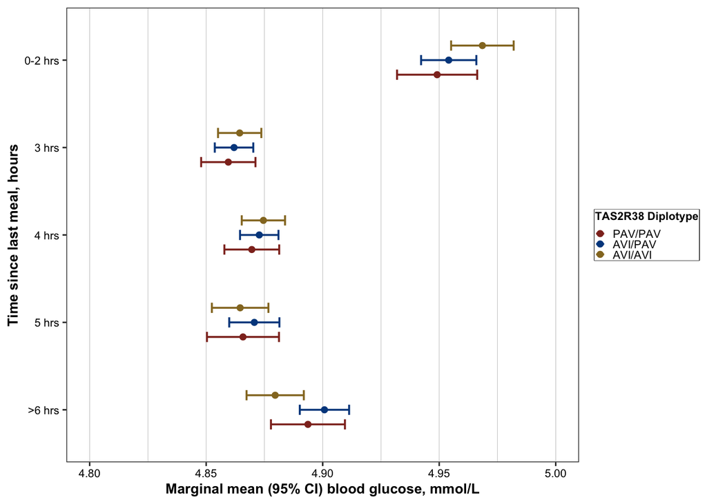

## Sensitivity Analyses

#### Summarize results for analysis restricting to plausible total energy intakes

| Model | Diplotype | n | Beta_95CI_RG | P_RG | Ftest_P_RG | Ttest_P_RG | Beta_95CI_HbA1c | P_HbA1c | Ftest_P_HbA1c | Ttest_P_HbA1c |
| --- | --- | --- | --- | --- | --- | --- | --- | --- | --- | --- |
| Base_AVI/AVI | AVI/AVI | 30132 | Reference | NA | 0.040 | 0.009 | Reference | NA | 0.464 | 0.316 |
| Base_AVI/PAV | AVI/PAV | 43387 | -0.007 (-0.016, 0.002) | 0.104 | NA | NA | 0.001 (-0.003, 0.005) | 0.558 | NA | NA |
| Base_PAV/PAV | PAV/PAV | 15750 | -0.015 (-0.027, -0.004) | 0.010 | NA | NA | 0.003 (-0.002, 0.008) | 0.321 | NA | NA |
| BMI_AVI/AVI | AVI/AVI | 30132 | Reference | NA | 0.040 | 0.008 | Reference | NA | 0.461 | 0.316 |
| BMI_AVI/PAV | AVI/PAV | 43387 | -0.007 (-0.016, 0.001) | 0.097 | NA | NA | 0.001 (-0.003, 0.005) | 0.578 | NA | NA |
| BMI_PAV/PAV | PAV/PAV | 15750 | -0.015 (-0.027, -0.004) | 0.010 | NA | NA | 0.003 (-0.002, 0.008) | 0.317 | NA | NA |
| Lifestyle_AVI/AVI | AVI/AVI | 30132 | Reference | NA | 0.039 | 0.011 | Reference | NA | 0.459 | 0.348 |
| Lifestyle_AVI/PAV | AVI/PAV | 43387 | -0.007 (-0.016, 0.001) | 0.097 | NA | NA | 0.001 (-0.003, 0.005) | 0.581 | NA | NA |
| Lifestyle_PAV/PAV | PAV/PAV | 15750 | -0.015 (-0.026, -0.003) | 0.014 | NA | NA | 0.002 (-0.003, 0.007) | 0.353 | NA | NA |
| Diet.Patterns_AVI/AVI | AVI/AVI | 30132 | Reference | NA | 0.039 | 0.014 | Reference | NA | 0.457 | 0.363 |
| Diet.Patterns_AVI/PAV | AVI/PAV | 43387 | -0.007 (-0.016, 0.001) | 0.095 | NA | NA | 0.001 (-0.003, 0.005) | 0.571 | NA | NA |
| Diet.Patterns_PAV/PAV | PAV/PAV | 15750 | -0.014 (-0.025, -0.002) | 0.018 | NA | NA | 0.002 (-0.003, 0.007) | 0.372 | NA | NA |

| model | fast | Diplo | n | beta_se | p | f_p | t_p |
| --- | --- | --- | --- | --- | --- | --- | --- |
| Base | 0to2hr | AVI/AVI | 7797 | NA (NA, NA) | NA | 0.0224706 | 0.0032886 |
| Base | 0to2hr | AVI/PAV | 11243 | -0.025 (-0.048, -0.002) | 0.0331956 | NA | NA |
| Base | 0to2hr | PAV/PAV | 4024 | -0.043 (-0.074, -0.013) | 0.0053078 | NA | NA |
| BMI | 0to2hr | AVI/AVI | 7797 | NA (NA, NA) | NA | 0.0216676 | 0.0032968 |
| BMI | 0to2hr | AVI/PAV | 11243 | -0.026 (-0.049, -0.003) | 0.0280031 | NA | NA |
| BMI | 0to2hr | PAV/PAV | 4024 | -0.043 (-0.073, -0.012) | 0.0056637 | NA | NA |
| Lifestyle | 0to2hr | AVI/AVI | 7797 | NA (NA, NA) | NA | 0.0215314 | 0.0036033 |
| Lifestyle | 0to2hr | AVI/PAV | 11243 | -0.026 (-0.049, -0.003) | 0.0281917 | NA | NA |
| Lifestyle | 0to2hr | PAV/PAV | 4024 | -0.042 (-0.073, -0.012) | 0.0062338 | NA | NA |
| Diet.Patterns | 0to2hr | AVI/AVI | 7797 | NA (NA, NA) | NA | 0.0213652 | 0.0049752 |
| Diet.Patterns | 0to2hr | AVI/PAV | 11243 | -0.025 (-0.048, -0.002) | 0.0307010 | NA | NA |
| Diet.Patterns | 0to2hr | PAV/PAV | 4024 | -0.041 (-0.071, -0.01) | 0.0086354 | NA | NA |
| Base | 3hr | AVI/AVI | 9378 | NA (NA, NA) | NA | 0.6284846 | 0.2867652 |
| Base | 3hr | AVI/PAV | 13357 | -0.007 (-0.022, 0.008) | 0.3581263 | NA | NA |
| Base | 3hr | PAV/PAV | 4872 | -0.01 (-0.029, 0.01) | 0.3332572 | NA | NA |
| BMI | 3hr | AVI/AVI | 9378 | NA (NA, NA) | NA | 0.6251446 | 0.2154592 |
| BMI | 3hr | AVI/PAV | 13357 | -0.008 (-0.023, 0.007) | 0.2832775 | NA | NA |
| BMI | 3hr | PAV/PAV | 4872 | -0.011 (-0.031, 0.008) | 0.2610773 | NA | NA |
| Lifestyle | 3hr | AVI/AVI | 9378 | NA (NA, NA) | NA | 0.6239197 | 0.2592511 |
| Lifestyle | 3hr | AVI/PAV | 13357 | -0.008 (-0.023, 0.007) | 0.2857696 | NA | NA |
| Lifestyle | 3hr | PAV/PAV | 4872 | -0.01 (-0.029, 0.01) | 0.3187073 | NA | NA |
| Diet.Patterns | 3hr | AVI/AVI | 9378 | NA (NA, NA) | NA | 0.6228362 | 0.2818880 |
| Diet.Patterns | 3hr | AVI/PAV | 13357 | -0.008 (-0.023, 0.007) | 0.2846782 | NA | NA |
| Diet.Patterns | 3hr | PAV/PAV | 4872 | -0.009 (-0.029, 0.01) | 0.3492801 | NA | NA |
| Base | 4hr | AVI/AVI | 6778 | NA (NA, NA) | NA | 0.2924009 | 0.4398968 |
| Base | 4hr | AVI/PAV | 9763 | 0.012 (-0.002, 0.027) | 0.1016837 | NA | NA |
| Base | 4hr | PAV/PAV | 3543 | 0.004 (-0.015, 0.024) | 0.6754608 | NA | NA |
| BMI | 4hr | AVI/AVI | 6778 | NA (NA, NA) | NA | 0.2918769 | 0.4384421 |
| BMI | 4hr | AVI/PAV | 9763 | 0.013 (-0.002, 0.028) | 0.0916560 | NA | NA |
| BMI | 4hr | PAV/PAV | 3543 | 0.004 (-0.016, 0.024) | 0.6840758 | NA | NA |
| Lifestyle | 4hr | AVI/AVI | 6778 | NA (NA, NA) | NA | 0.2901637 | 0.4668489 |
| Lifestyle | 4hr | AVI/PAV | 9763 | 0.012 (-0.003, 0.027) | 0.1071834 | NA | NA |
| Lifestyle | 4hr | PAV/PAV | 3543 | 0.004 (-0.016, 0.023) | 0.7083027 | NA | NA |
| Diet.Patterns | 4hr | AVI/AVI | 6778 | NA (NA, NA) | NA | 0.2893807 | 0.4532366 |
| Diet.Patterns | 4hr | AVI/PAV | 9763 | 0.012 (-0.003, 0.027) | 0.1144253 | NA | NA |
| Diet.Patterns | 4hr | PAV/PAV | 3543 | 0.004 (-0.015, 0.024) | 0.6819623 | NA | NA |
| Base | 5hr | AVI/AVI | 3541 | NA (NA, NA) | NA | 0.4908950 | 0.2142079 |
| Base | 5hr | AVI/PAV | 5057 | -0.011 (-0.031, 0.009) | 0.2733664 | NA | NA |
| Base | 5hr | PAV/PAV | 1824 | -0.015 (-0.041, 0.011) | 0.2630260 | NA | NA |
| BMI | 5hr | AVI/AVI | 3541 | NA (NA, NA) | NA | 0.4906167 | 0.2312216 |
| BMI | 5hr | AVI/PAV | 5057 | -0.011 (-0.03, 0.009) | 0.2874692 | NA | NA |
| BMI | 5hr | PAV/PAV | 1824 | -0.014 (-0.04, 0.012) | 0.2816950 | NA | NA |
| Lifestyle | 5hr | AVI/AVI | 3541 | NA (NA, NA) | NA | 0.4887238 | 0.2766421 |
| Lifestyle | 5hr | AVI/PAV | 5057 | -0.011 (-0.03, 0.009) | 0.2895219 | NA | NA |
| Lifestyle | 5hr | PAV/PAV | 1824 | -0.013 (-0.038, 0.013) | 0.3418123 | NA | NA |
| Diet.Patterns | 5hr | AVI/AVI | 3541 | NA (NA, NA) | NA | 0.4877025 | 0.2867816 |
| Diet.Patterns | 5hr | AVI/PAV | 5057 | -0.011 (-0.03, 0.009) | 0.2910943 | NA | NA |
| Diet.Patterns | 5hr | PAV/PAV | 1824 | -0.012 (-0.038, 0.014) | 0.3547387 | NA | NA |
| Base | 6+hr | AVI/AVI | 2638 | NA (NA, NA) | NA | 0.7806853 | 0.6571648 |
| Base | 6+hr | AVI/PAV | 3967 | 0 (-0.023, 0.023) | 0.9920430 | NA | NA |
| Base | 6+hr | PAV/PAV | 1487 | -0.008 (-0.037, 0.022) | 0.6139924 | NA | NA |
| BMI | 6+hr | AVI/AVI | 2638 | NA (NA, NA) | NA | 0.7804438 | 0.6724198 |
| BMI | 6+hr | AVI/PAV | 3967 | 0 (-0.023, 0.022) | 0.9655140 | NA | NA |
| BMI | 6+hr | PAV/PAV | 1487 | -0.007 (-0.036, 0.022) | 0.6370107 | NA | NA |
| Lifestyle | 6+hr | AVI/AVI | 2638 | NA (NA, NA) | NA | 0.7791312 | 0.7309330 |
| Lifestyle | 6+hr | AVI/PAV | 3967 | -0.001 (-0.023, 0.022) | 0.9525404 | NA | NA |
| Lifestyle | 6+hr | PAV/PAV | 1487 | -0.006 (-0.035, 0.023) | 0.7057620 | NA | NA |
| Diet.Patterns | 6+hr | AVI/AVI | 2638 | NA (NA, NA) | NA | 0.7789070 | 0.8022867 |
| Diet.Patterns | 6+hr | AVI/PAV | 3967 | 0 (-0.023, 0.022) | 0.9753894 | NA | NA |
| Diet.Patterns | 6+hr | PAV/PAV | 1487 | -0.004 (-0.033, 0.025) | 0.7808717 | NA | NA |